# Chapter 3 homework

Author

Judah Altman

## Setup

```r
library(tidyverse)
library(here)
library(broom)
library(gssrdoc)
```

The course datasets live in your project’s `data/` folder. Use `here::here()` so file paths work regardless of where you render from.

```r
fitness <- readr::read_csv(here::here("data", "fitness.csv"))
```

## 1. Is this a “normal” group (resting pulse)?

The dataset `fitness.csv` contains (among other variables) resting pulse rate (`RSTPULSE`) for a sample of men. A commonly cited “normal” resting pulse rate for men is 72. We want to assess whether this sample looks consistent with that reference value.

### (a) Specify MODEL C, MODEL A, and the null hypothesis

Write both a verbal description and a mathematical statement.

- **MODEL C (compact):** predicts the reference value for every case
  $$\text{RSTPULSE}_i = 72 + \varepsilon_i$$
- **MODEL A (augmented):** estimates the sample mean (one-parameter model)
  $$\text{RSTPULSE}_i = b_0 + \varepsilon_i$$
- **Null hypothesis:** $H_0: b_0 = 72$ (equivalently, the population mean resting pulse equals 72)

### (b) Estimate both models with `lm()`

A convenient way to fit these with `lm()` is to *re-express* the outcome as a deviation from the null value.

Let $Y_i = \text{RSTPULSE}_i - 72$. Then:

- MODEL C becomes $Y_i = 0 + \varepsilon_i$ (0 parameters)
- MODEL A becomes $Y_i = b_0 + \varepsilon_i$ (1 parameter)

```r
fitness <- fitness |>
  mutate(rst_dev = RSTPULSE - 72)

model_c <- lm(rst_dev ~ 0, data = fitness)
model_a <- lm(rst_dev ~ 1, data = fitness)

summary(model_c)
```

```
Call:
lm(formula = rst_dev ~ 0, data = fitness)

Residuals:
   Min     1Q Median     3Q    Max
 -32.0  -24.0  -20.0  -13.5    4.0

No Coefficients

Residual standard error: 20 on 31 degrees of freedom
```

```r
summary(model_a)
```

```
Call:
lm(formula = rst_dev ~ 1, data = fitness)

Residuals:
    Min      1Q  Median      3Q     Max
-13.742  -5.742  -1.742   4.758  22.258

Coefficients:
            Estimate Std. Error t value Pr(>|t|)
(Intercept)   -18.26       1.49  -12.26 3.29e-13 ***
---
Signif. codes:  0 '***' 0.001 '**' 0.01 '*' 0.05 '.' 0.1 ' ' 1

Residual standard error: 8.294 on 30 degrees of freedom
```

```r
broom::tidy(model_a)
```

```
# A tibble: 1 × 5
  term        estimate std.error statistic  p.value
  <chr>          <dbl>     <dbl>     <dbl>    <dbl>
1 (Intercept)    -18.3      1.49     -12.3 3.29e-13
```

```r
broom::glance(model_a)
```

```
# A tibble: 1 × 12
  r.squared adj.r.squared sigma statistic p.value    df logLik   AIC   BIC
      <dbl>         <dbl> <dbl>     <dbl>   <dbl> <dbl>  <dbl> <dbl> <dbl>
1         0             0  8.29        NA      NA    NA  -109.  222.  225.
# ℹ 3 more variables: deviance <dbl>, df.residual <int>, nobs <int>
```

### (c) Calculate PRE

Use:

$$\text{PRE} = \frac{\text{SSE}_C - \text{SSE}_A}{\text{SSE}_C}$$

For `lm` objects, you can get SSE (a.k.a. RSS) with `deviance()`.

```r
sse_c <- deviance(model_c)
sse_a <- deviance(model_a)

pre <- (sse_c - sse_a) / sse_c
pre
```

```
[1] 0.8335267
```

### (d) Write a tentative summary

In a short paragraph, summarize what you found and what it suggests substantively. (We are not doing a formal test yet—use your judgment.)

From the Proportional Reduction in Error, Model A improves the prediction of Model C by ~83%, so it improves on Model C and likely should be accepted in favor of the null hypothesis (pending further testing). This is because in the data, the mean resting pulse is 18.26 beats (per minute?) less than the model C guess of 72 which is a significant difference, so the model is improved by accounting for the average resting pulse of this sample, rather than guessing/citing the usually cited resting pulse of 72.

## 2. Did running increase pulse rate?

Use the same dataset to assess whether running increased pulse rate. The variable `RUNPULSE` is post-run pulse rate.

Tip: Create a new variable that captures the *change* in pulse rate.

### (a) Specify MODEL C, MODEL A, and the null hypothesis

Let $\Delta_i = \text{RUNPULSE}_i - \text{RSTPULSE}_i$.

- **MODEL C (compact):** no average increase
  $$\Delta_i = 0 + \varepsilon_i$$
- **MODEL A (augmented):** estimate the average increase
  $$\Delta_i = b_0 + \varepsilon_i$$
- **Null hypothesis:** $H_0: b_0 = 0$

### (b) Estimate both models with `lm()`

```r
fitness <- fitness |>
  mutate(pulse_change = RUNPULSE - RSTPULSE)

model_c <- lm(pulse_change ~ 0, data = fitness)
model_a <- lm(pulse_change ~ 1, data = fitness)

summary(model_c)
```

```
Call:
lm(formula = pulse_change ~ 0, data = fitness)

Residuals:
   Min     1Q Median     3Q    Max
  92.0  111.0  116.0  123.5  136.0

No Coefficients

Residual standard error: 116.4 on 31 degrees of freedom
```

```r
summary(model_a)
```

```
Call:
lm(formula = pulse_change ~ 1, data = fitness)

Residuals:
     Min       1Q   Median       3Q      Max
-23.9032  -4.9032   0.0968   7.5968  20.0968

Coefficients:
            Estimate Std. Error t value Pr(>|t|)
(Intercept)  115.903      1.966   58.95   <2e-16 ***
---
Signif. codes:  0 '***' 0.001 '**' 0.01 '*' 0.05 '.' 0.1 ' ' 1

Residual standard error: 10.95 on 30 degrees of freedom
```

```r
broom::tidy(model_a)
```

```
# A tibble: 1 × 5
  term        estimate std.error statistic  p.value
  <chr>          <dbl>     <dbl>     <dbl>    <dbl>
1 (Intercept)     116.      1.97      59.0 1.40e-32
```

```r
broom::glance(model_a)
```

```
# A tibble: 1 × 12
  r.squared adj.r.squared sigma statistic p.value    df logLik   AIC   BIC
      <dbl>         <dbl> <dbl>     <dbl>   <dbl> <dbl>  <dbl> <dbl> <dbl>
1         0             0  10.9        NA      NA    NA  -118.  239.  242.
# ℹ 3 more variables: deviance <dbl>, df.residual <int>, nobs <int>
```

### (c) Calculate PRE

```r
sse_c <- deviance(model_c)
sse_a <- deviance(model_a)

pre <- (sse_c - sse_a) / sse_c
pre
```

```
[1] 0.9914419
```

### (d) Write a tentative summary

In a short paragraph, summarize what you found and what it suggests substantively.

From the Proportional Reduction in Error, Model A improves the prediction of Model C by ~99%, so it improves on Model C and likely should be accepted in favor of the null hypothesis (pending further testing). This is because in the data, the mean pulse change from running versus resting is on average 116 beats per minute higher than at a resting state. The model C guess that said there is no difference between running and resting pulse does not account for this change as it hypothesizes as the null hypothesis that it is 0, so the model is improved by accounting for the the fact that there is an average change in resting pulse between running and resting, and therefore the null hypothesis that there is no change can be rejected in favor the hypothesis that running increases your pulse rate.

## 3. Conceptual practice: write models and hypotheses

For each prompt below:

1. Specify MODEL C, MODEL A, and the null hypothesis.
2. State the number of parameters in MODEL C and MODEL A.
3. State the number of **unused-but-potential parameters** in MODEL A (degrees of freedom), using the course definition.

Do **not** write your models generically as “$Y = \dots$”. Use the named dependent variable (e.g., “IQ”, “PTSD score”, etc.). If a prompt implies a *constructed variable*, define it.

### (a) IQ

IQ tests are designed to have mean 100 and standard deviation 15. You give 6 friends an online IQ test. Are your friends smarter than average?

1. **MODEL C (compact):** uses the intended mean IQ to predict the reference value for every case
   $$IQ_i = 100 + \varepsilon_i$$
- **MODEL A (augmented):** uses the sample mean of the 6 friends to estimate their group IQ (one-parameter model)
  $$IQ_i = IQ_\mu + \varepsilon_i$$
- **Null hypothesis:** $H_0: IQ_\mu = 100$ (equivalently, the average of the 6 friends’ online IQ test is 100). The null hypothesis can be rejected if the friends are smarter than average (mean is significantly over 100) or are stupider than average (mean is significantly below 100)
2. Model C has 0 parameters, model A has 1 parameter.
3. Model A has a degree of freedom of 5, as there are 6 potential parameters, 1 used parameter, so 6 - 1 = 5, which is the total number of unused parameters that could have been in Model A.

### (b) PTSD

The army uses a PTSD test; scores above 37 indicate clinical levels of PTSD. A troop of 43 soldiers is tested at the end of deployment. Are these soldiers, on average, suffering from PTSD?

Let $\Delta_i = PTSD_\text{score} - 37$.

1. **MODEL C (compact):** predicts the change in PTSD scores, a score above 0 means the group has PTSD, a score below means they do not
   $$\Delta_i = 0 + \varepsilon_i$$
- **MODEL A (augmented):** estimates the average increase of the soldiers tested, where $\Delta_i = PTSD_\text{soldiers} - 37_i$ (one-parameter model) and $b_0$ is the average increase or decrease indicating if the soldiers on average suffer from PTSD or not
  $$\Delta_i = b_0 + \varepsilon_i$$
- **Null hypothesis:** $H_0: PTSD_\mu = 37$ (equivalently, the average of the 43 soldiers PTSD levels are 37). The null hypothesis can be rejected if the PTSD levels are higher than average (mean is significantly over 37) or are lower than average (mean is significantly below 37)
2. Model C has 0 parameters, model A has 1 parameter.
3. Model A has a degree of freedom of 42, as there are 43 potential parameters, 1 used parameter, so 43 - 1 = 42, which is the total number of unused parameters that could have been in Model A.

### (c) Chipotle sales

Chipotle wants to know whether sales have rebounded after an E. coli scare. They have sales in 200 markets *before* the scare and *now*. They compute a difference score. Are sales depressed?

1. **MODEL C (compact):** uses the actual number of markets before E. coli to predict how many markets Chipotle has sales in now
   $$Markets_i = 200 + \varepsilon_i$$
- **MODEL A (augmented):** uses the presence of absence of E. coli to estimate how many more or less markets Chipotle has sales in, where $Markets_\text{total}$ is a count of markets with sales (one-parameter model)
  $$Markets_i = Markets_\text{total} + \varepsilon_i$$
- **Null hypothesis:** $H_0: Markets_i = 200$ (equivalently, the sales after E. Coli will equal 200). The null hypothesis can be rejected if there are way more or less markets with sales than 200.
2. Model C has 0 parameters, model A has 1 parameter.
3. Model A under this model has degrees of freedom up to the total number of possible markets that Chipotle could reach - 1, as there is 1 parameter, so the last prediction will be determined.

## 4. With your own data

Please choose a variable from the 2024 General Social Survey. Remember to use `drop_na()` in your pipeline to get rid of missing data.

### (a) Describe your dataset

Include enough detail that someone else can understand what you have.

I chose the variable eqwlth, which is: ‘Should govt reduce income difference?’

- **(a.1)** What are the units of analysis and how many are there?

The unit of analyis are the individuals taking the survey. There are 2161 individuals who answered the question for this variable in 2024.

- **(a.2)** What is the dependent variable ($Y$)? How is it measured? What does its distribution look like? (A histogram and/or descriptives are fine.)

The dependent is the extent to which the individuals agree with this statement, between 1 and 7, where 1 is the government should reduce income differences, and 7 is the government should not concern itself with reducing income differences. It is measured on an ordinal scale, with individuals selecting the extent to which they lean one way or the other on the topic. It’s distribution is higher at 1, normally distributed between 2 and 6, and higher again at 7.

```r
# If you have data loaded, you can start with something like:
# your_data |>
#   summarize(
#     n = n(),
#     mean_y = mean(Y, na.rm = TRUE),
#     sd_y = sd(Y, na.rm = TRUE)
#   )

gss2024 <- readRDS(here("data", "gss2024.rds"))

df <- gss2024 |>
  select(eqwlth) |>
  drop_na() |>
  haven::zap_labels()

df |>
  summarize(n = n(),
            mean_eqwlth = mean(eqwlth),
            sd_eqwlth = sd(eqwlth))
```

```
# A tibble: 1 × 3
      n mean_eqwlth sd_eqwlth
  <int>       <dbl>     <dbl>
1  2161        3.40      2.18
```

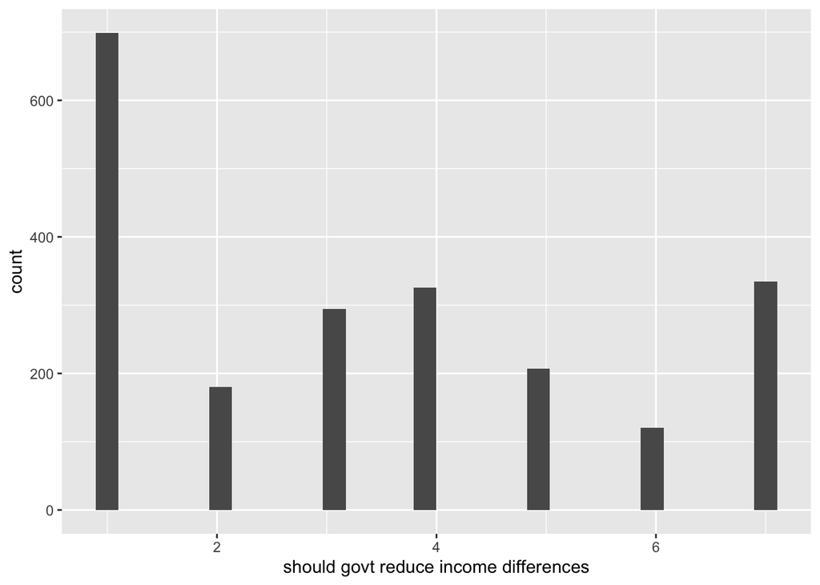

```r
ggplot(df, aes(x = eqwlth)) +
  geom_histogram()
```

### (b) Propose a one-parameter question

Think of a question that can be tested with a MODEL C with **0 parameters** and a MODEL A that uses **1 parameter** to estimate central tendency. Write the research question in plain language.

To what extent does the average belief in the governments involvement in reducing income differences diverge from the middle perspective that the government should be somewhat involved and somewhat not involved?

### (c) Specify MODEL A, MODEL C, and the null hypothesis

Write both a verbal description and a mathematical statement (use $\varepsilon_i$ for error).

```r
# Replace Y with your dependent variable and adapt as needed.
# If your null value is mu0, you can use the same deviation trick as in Question 1:
#
# your_data <- your_data |>
#   mutate(y_dev = Y - mu0)
#
# model_c <- lm(y_dev ~ 0, data = your_data)
# model_a <- lm(y_dev ~ 1, data = your_data)
#
# summary(model_c)
# summary(model_a)

df <- df |>
  mutate(eqwlth_dev = eqwlth - 4)

model_c <- lm(eqwlth_dev ~ 0, data = df)
model_a <- lm(eqwlth_dev ~ 1, data = df)

summary(model_c)
```

```
Call:
lm(formula = eqwlth_dev ~ 0, data = df)

Residuals:
   Min     1Q Median     3Q    Max
    -3     -3     -1      1      3

No Coefficients

Residual standard error: 2.257 on 2161 degrees of freedom
```

```r
summary(model_a)
```

```
Call:
lm(formula = eqwlth_dev ~ 1, data = df)

Residuals:
    Min      1Q  Median      3Q     Max
-2.3989 -2.3989 -0.3989  1.6011  3.6011

Coefficients:
            Estimate Std. Error t value Pr(>|t|)
(Intercept) -0.60111    0.04681  -12.84   <2e-16 ***
---
Signif. codes:  0 '***' 0.001 '**' 0.01 '*' 0.05 '.' 0.1 ' ' 1

Residual standard error: 2.176 on 2160 degrees of freedom
```

### (e) Calculate PRE

```r
# sse_c <- deviance(model_c)
# sse_a <- deviance(model_a)
# pre <- (sse_c - sse_a) / sse_c
# pre

sse_c <- deviance(model_c)
sse_a <- deviance(model_a)
pre <- (sse_c - sse_a) / sse_c
pre
```

```
[1] 0.07094055
```

## Submission

Render this document to **PDF** and submit the PDF with your code and output.